# 動画から背景画像を消す処理の内容理解

## 背景差分を表示するチュートリプログラムを調査する

背景差分を表示するチュートリアルサンプル：https://docs.opencv.org/4.0.0/db/d5c/tutorial_py_bg_subtraction.html

画像の特定の領域を表示するプログラムを調べていたところOpenCVには`cv2.bitwise_and`という名前の関数があり，mask画像が白色の領域だけ画像を切り出せることがわかった

lecture07_ImageMask.py

```python
#!/usr/bin/env python
# -*- coding: utf-8 -*-

import numpy as np
import cv2

img = cv2.imread('uchitane_near.png',cv2.IMREAD_COLOR)
rows, cols, channels = img.shape
# print(f"画像の大きさは幅{cols}px x 縦{rows}px")
mask = np.zeros((rows, cols, channels), dtype=np.uint8)
mask[0:int(rows/2),:] = [255 for i in range(channels)] # yの上半分を白に，下半分は黒(0,0,0)のまま

# このプログラムの主役
# imgの特定の領域だけを切り出すようにmask画像を利用する
img_AND = cv2.bitwise_and(img, mask)

cv2.imshow('masked_img',img_AND)
cv2.waitKey(0) # なにかキーが押されるまで待機
cv2.destroyAllWindows()
```

## 実行結果

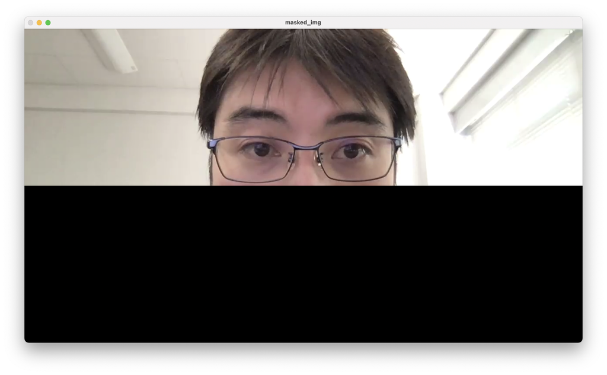

## 解説

mask画像で領域を指定することで画像の一部を抜き出すことができることがわかった

動画から動きのあった箇所 and 画像に含まれるエッジの箇所を残すようにmaskを作ることができればzoomのように背景を別の画像(例えば資料04で考えたエッジのみの背景)で置き換えられるかもしれない

課題では画像を小さな矩形(16px x 16px)の区域に分けて，その区域で動きがあるかどうか（時間差分画像の特定区域に動きが大きい画素が数多く含まれているか？）を元に背景となる領域を消してみる

## まとめ

OpenCVでは画像の特定の領域を残すために，領域を指定するmask画像を作成しcv2.bitwise_and関数を利用する

ビデオ会議での背景画像を消す処理を作るために，課題では動画の必要な領域（区分）だけを残す処理を考えていく